# 03_eda_junio_html

## Catastro Minero de Salta

### Notebook 01: EDA y Limpieza de Datos

### Proyecto: Análisis del catastro minero oficial de la provincia de Salta, Argentina

Fuente: Geoportal oficial de Salta

### Autora: Camila Mopty

#### Fecha: 2026

```
El repositorio ya existe en el entorno.
```

```
✓ Todas las dependencias instaladas correctamente.
```

## 3. EDA- Exploración inicial

*Dataset catastro minero completo*

|  | Column | Non-Null Count | Dtype |
| --- | --- | --- | --- |
| 0 | fid | 3953 | int32 |
| 1 | tipo | 3953 | object |
| 2 | expediente | 3951 | object |
| 3 | nombre | 3866 | object |
| 4 | mineral | 3350 | object |
| 5 | concesiona | 3576 | object |
| 6 | estado | 3953 | object |
| 7 | resolucion | 96 | object |
| 8 | fecha_inic | 3778 | datetime64[ms] |
| 9 | departamen | 3952 | object |
| 10 | municipio | 3904 | object |
| 11 | lugar | 3398 | object |
| 12 | area | 3953 | object |
| 13 | coordenada | 3953 | object |
| 14 | geometry | 3953 | geometry |

Valores de tipo y de estado

```
Tipo: ['Convenio' 'Mina' 'Manifestacion' 'Servidumbre' 'Cateo' 'Cantera'
 'Zona de Investigación Geológica Minera' 'Grupo Minero']
estado: ['Vigente' 'Vacante' 'Anulación de registro sin publicar (REMSa)'
 'Anulación de registro sin publicar']
```

El Código de Minería de la República Argentina, aprobado por Ley N° 1919 define:

### Tipo

- Cateo: Es un derecho temporal exclusivo para realizar trabajos de búsqueda y prospección de minerales en un área determinada con excavaciones de prueba.
- Manifestación: Es el acto formal y técnico donde el cateador notifica el hallazgo de un yacimiento nuevo. Genera prioridad legal sobre el terreno para transformar el cateo en una concesión de mina.
- Mina: Es la propiedad minera propiamente dicha, concedida por el Estado de manera perpetua. Explotación de sustancias de primera y segunda categoría.
- Cantera:Explotación de sustancias de Tercera Categoría (minerales industriales, rocas de aplicación, arenas, piedras de construcción).
- Grupo Minero: Es la unificación catastral y operativa de dos o más pertenencias de minas contiguas para ser explotadas bajo un único plan de trabajos unificado.
- Servidumbre: Derecho de ocupación o uso que la ley le concede al minero sobre los terrenos superficiales para caminos de acceso, acueductos, tendidos eléctricos o campamentos, con previa indemnización al propietario.
- Zona de Investigación Geológica Minera: Áreas reservadas temporalmente por el Estado (o corporaciones estatales delegadas) para que organismos oficiales de investigación geológica realicen prospecciones a gran escala. Durante la vigencia de esta zona, queda suspendida la admisión de peticiones de cateos o manifestaciones de descubrimiento por parte de particulares.

### Estado

- Vigente: El derecho minero se encuentra plenamente activo y válido.
- Vacante: El derecho minero previo ha caducado, ha sido revocado o el plazo del cateo expiró y el área ya ha sido liberada formalmente mediante publicación en el Boletín Oficial.
- Anulación de registro sin publicar: La Autoridad Minera ya ha dictado la resolución de caducidad o rechazo ese expediente pero aún no se ha publicado en el Boletín Oficial.
- Anulación de registro sin publicar (REMSa): una mina cae en caducidad y el Juzgado de Minas dicta la anulación del registro, pero el área no se libera para el público general sino que se transfiere preferencialmente a la empresa estatal REMSa S.A. para que esta evalúe su potencial y la someta a licitación o concurso público de proyectos.

```
            nulos/vacios  porcentaje
resolucion          3857        97.6
mineral              603        15.3
lugar                555        14.0
concesiona           377         9.5
fecha_inic           175         4.4
nombre                87         2.2
municipio             49         1.2
expediente             2         0.1
estado                 0         0.0
fid                    0         0.0
tipo                   0         0.0
departamen             1         0.0
area                   0         0.0
coordenada             0         0.0
geometry               0         0.0
```

### Clasificación

*Dataset con datos en el atributo tipo de mineral*

```
Dataset completo:           3,953 registros
Dataset con mineral:        3,350 registros
Registros excluidos:        603
```

```
            nulos/vacios  porcentaje
resolucion          3260        97.3
concesiona           279         8.3
lugar                263         7.9
fecha_inic           135         4.0
nombre                72         2.1
expediente             2         0.1
fid                    0         0.0
tipo                   0         0.0
estado                 0         0.0
mineral                0         0.0
departamen             0         0.0
municipio              1         0.0
area                   0         0.0
coordenada             0         0.0
geometry               0         0.0
area_ha                0         0.0
```

## Clasificación de pedimetos con minerales críticos

```
Dataset completo:           3,953 registros
Dataset con mineral:        3,350 registros
Dataset con minerales criticos: 2,053 registros
Registros excluidos:        1,297
```

Valores de tipo y estado

```
Tipo: ['Mina' 'Manifestacion']
estado: ['Vacante' 'Vigente' 'Anulación de registro sin publicar (REMSa)'
 'Anulación de registro sin publicar']
```

# Tablas resumen

```
============================================================
  1 · Totales generales
============================================================
```

| Indicador | Minerales críticos | Sin minerales críticos | Total |
| --- | --- | --- | --- |
| Total pedimentos | 2053.00 | 1297.00 | 3350.00 |
| Superficie total (ha) | 2851858.52 | 549464.25 | 3401322.77 |

```
============================================================
  2 · Distribución por tipo
============================================================
```

| Tipo | Minerales críticos | Sin minerales críticos | Total |
| --- | --- | --- | --- |
| Mina | 1214 | 440 | 1654 |
| Manifestacion | 839 | 198 | 1037 |
| Cantera | 0 | 491 | 491 |
| Convenio | 0 | 168 | 168 |

```
============================================================
  3 · Distribución por estado
============================================================
```

| Estado | Minerales críticos | Sin minerales críticos | Total |
| --- | --- | --- | --- |
| Vigente | 1952 | 1232 | 3184 |
| Vacante | 85 | 55 | 140 |
| Anulación de registro sin publicar (REMSa) | 8 | 5 | 13 |
| Anulación de registro sin publicar | 8 | 5 | 13 |

## 5. Gráficos

**5.1. Cantidad total de pedimentos según departamentos - gráfico de barras**

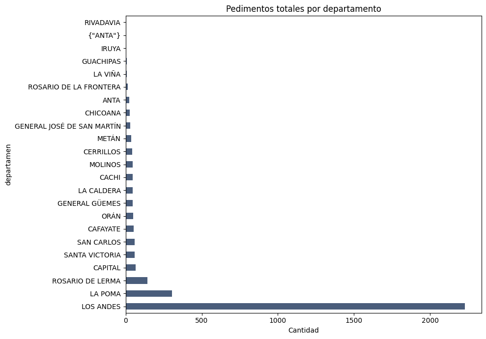

**5.2. Cantidad total de pedimentos según departamentos - gráfico de tortas**

[interactive chart not shown]

**5.3. Cantidad total de pedimentos con y sin minerales críticos - Gráfico de barras**

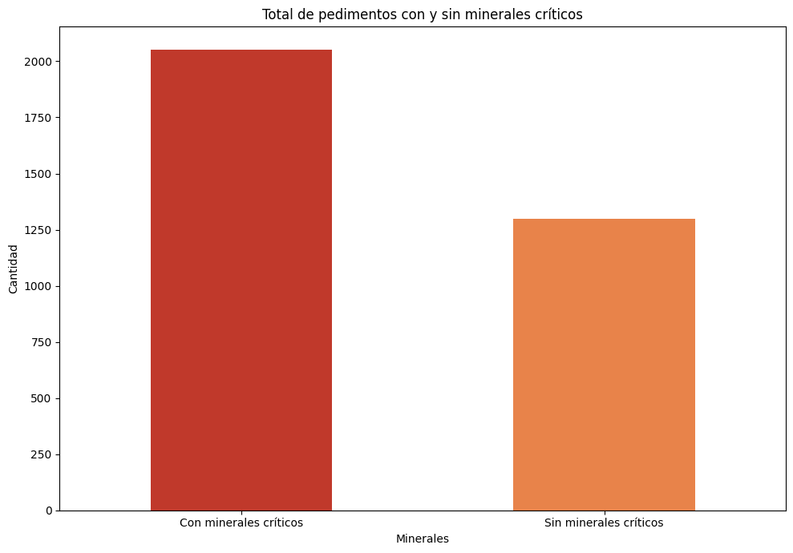

**5.4. Pedimentos con y sin minerales críticos según área por departamento - gráfico de barras apiladas**

[interactive chart not shown]

**5.5. Cantidad de Pedimentos con y sin mínerales críticos por año de iniciación (2009-2025) - Gráfico de barras apiladas**

[interactive chart not shown]

**5.6. Superficie de Pedimentos con y sin mínerales críticos por año de iniciación (2009-2025) - Gráfico de barras apiladas**

[interactive chart not shown]

**5.7. Cantidad de Pedimentos por tipo por año de iniciación (2009-2025) - Gráfico de barras apiladas**

```
array(['Mina', 'Manifestacion', 'Convenio', 'Cantera'], dtype=object)
```

[interactive chart not shown]

**5.8. Cantidad de Pedimentos tipo Mina por año con y sin minerales críticos**

[interactive chart not shown]

**5.9. Superficie de Pedimentos tipo Mina con y sin minerales criticos por año**

[interactive chart not shown]

**5.10. Cantidad de Pedimentos tipo Manifestación por año con y sin minerales críticos**

[interactive chart not shown]

**5.11. Superficie de Pedimentos tipo Manifestacion por año**

[interactive chart not shown]

**5.12. Localización de pedimentos con y sin minerales críticos - Mapa**

[interactive chart not shown]

**5.13. Localización de pedimentos según tipo con y sin minerales críticos - Mapa**

[interactive chart not shown]

**5.14. Top 20 actores con pedimentos con minerales críticos según cantidad y superficie (ha)**

[interactive chart not shown]

**5.16. Top 20 actores con minerales críticos según cantidad de pedimentos tipo Mina**

[interactive chart not shown]

**5.17. Top 20 actores con minerales críticos según cantidad de pedimentos tipo Mina**

[interactive chart not shown]